[O’Hara on GitHub](https://github.com/oharac)

# Biodiversity n and var two-panel figures

Compiled on Sat Aug 31 11:31:45 2019 by ohara

```r
knitr::opts_chunk$set(fig.width = 6, fig.height = 4, fig.path = 'figs/',
                      echo = TRUE, message = FALSE, warning = FALSE)

library(raster)
library(data.table)
library(sf)


source('https://raw.githubusercontent.com/oharac/src/master/R/common.R')  ###
  ### includes library(tidyverse); library(stringr); dir_M points to ohi directory

dir_git <- here()

source(file.path(dir_git, '_setup/common_fxns.R'))
```

# 1 Summary

Create a set of maps of the distribution of biodiversity intactness - all species assessed and mapped by IUCN. These maps are generated at 10 km<sup>2</sup> resolution in a Gall-Peters projection. These maps will be generated using all comprehensively-assessed species:

- S1: Number of species for mean/var calculations
- S3: Variance of risk

# 2 Data sources

- IUCN species API: IUCN. (2019). The IUCN Red List of Threatened Species. Version 2019-2.
- IUCN species shapefiles: IUCN. (2019). The IUCN Red List of Threatened Species. Version 2019-2. Retrieved August 2019, from http://www.iucnredlist.org
- BirdLife International shapefiles: BirdLife International and Handbook of the Birds of the World. (2018). Bird species distribution maps of the world. Version 7.0. Available at http://datazone.birdlife.org/species/requestdis
- Marine Ecoregions of the World: Spalding, M. D., Fox, H. E., Allen, G. R., Davidson, N., Ferdaña, Z. A., Finlayson, M. A. X., … others. (2007). Marine ecoregions of the world: A bioregionalization of coastal and shelf areas. BioScience, 57(7), 573–583.

# 3 Methods

## 3.1 Spatial distribution of N spp: comprehensively assessed spp

From the 1a and 1b biodiversity risk map scripts, gather the rasters for the various maps:

- N_spp risk (unweighted and range-rarity-weighted)
- Var risk (unweighted and range-rarity-weighted)

```r
nspp_un_rast <- raster(file.path(dir_output, 'n_spp_risk_raster_comp.tif'))
nspp_rr_rast <- raster(file.path(dir_output, 'sr_rr_risk_raster_comp.tif'))
var_un_rast  <- raster(file.path(dir_output, 'var_risk_raster_comp.tif'))
var_rr_rast  <- raster(file.path(dir_output, 'var_rr_risk_raster_comp.tif'))
```

### 3.1.1 And now, the maps

The four-panel map chunks create two maps, with two density plots as scales; first map is for uniform-weighting, second is for range-rarity weighting.

### 3.1.2 N spp maps

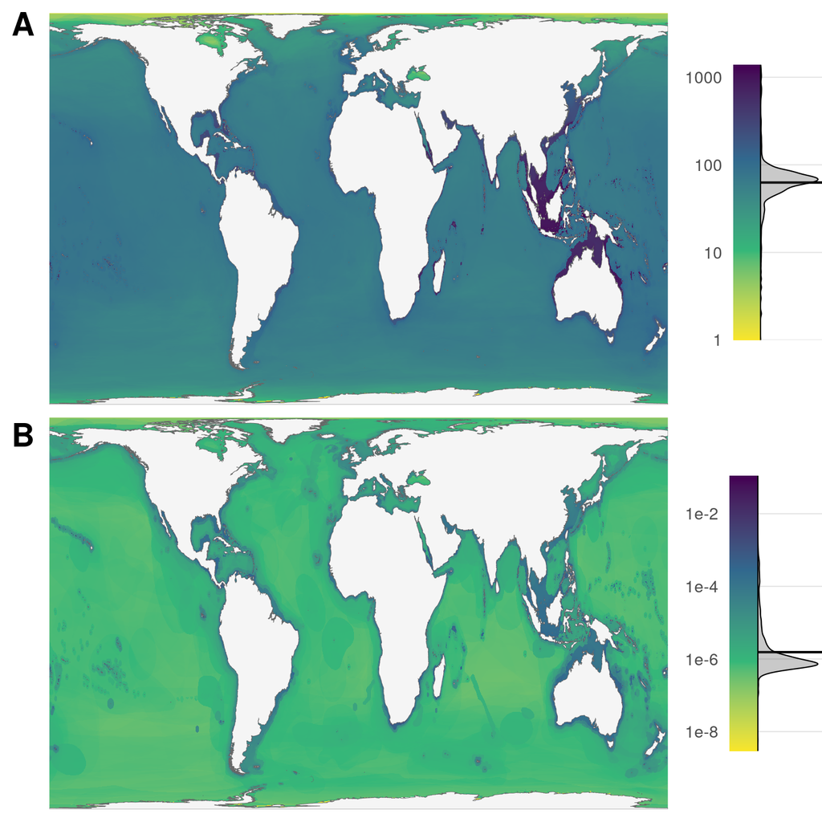

```r
### Log-transform nspp rasters for more interesting visual scaling
nspp_un_log <- log10(nspp_un_rast) # range 0, 3.146748
nspp_rr_log <- log10(nspp_rr_rast) # -8.23878, -0.9510185
### aggregate rasters for faster testing:
# nspp_un_rast <- nspp_un_rast %>% aggregate(10)
# nspp_rr_rast <- nspp_rr_rast %>% aggregate(10)

nspp_map_df <- data.frame(val_1 = values(nspp_un_log),
                     val_2 = values(nspp_rr_log)) %>%
  cbind(coordinates(nspp_un_log)) %>%
  filter(!is.na(val_1))

nspp_cols <- c(viridis::viridis(4, direction = -1))

### set up a dataframe of values to craft a color bar using geom_segment
### separate for each map due to incompatibility of scales
colorbar_df1 <- data.frame(x = seq(0, max(nspp_map_df$val_1),
                                   length.out = 1000),
                           y = -1)
lbls1 <- c(1, 10, 100, 1000)
brks1 <- c(0, 1, 2, 3)
lims1 <- c(0, max(nspp_map_df$val_1))

colorbar_df2 <- data.frame(x = seq(min(nspp_map_df$val_2),
                                   max(nspp_map_df$val_2),
                                   length.out = 1000),
                           y = -1)
lbls2 <- c('1e-8', '1e-6', '1e-4', '1e-2', '1')
brks2 <- c(-8, -6, -4, -2, 0)
lims2 <- c(min(nspp_map_df$val_2), max(nspp_map_df$val_2))


land_poly <- sf::read_sf(file.path(dir_spatial, 'ne_10m_land',
                                   'ne_10m_land_no_casp.shp')) %>%
  st_transform(gp_proj4)


map1 <- ggplot(nspp_map_df) +
  geom_raster(aes(x, y, fill = val_1), show.legend = FALSE) +
  geom_sf(data = land_poly, aes(geometry = geometry),
          fill = 'grey96', color = 'grey40', size = .10) +
  ggtheme_map() +
  theme(plot.margin = unit(c(.2, 0, .1, .5), units = 'cm')) +
  coord_sf(datum = NA) + ### ditch graticules
  scale_fill_gradientn(colors = nspp_cols, limits = lims1,
                       labels = lbls1, breaks = brks1) +
  scale_x_continuous(expand = c(0, 0)) +
  scale_y_continuous(expand = c(0, 0))

map2 <- ggplot(nspp_map_df) +
  geom_raster(aes(x, y, fill = val_2), show.legend = FALSE) +
  geom_sf(data = land_poly, aes(geometry = geometry),
          fill = 'grey96', color = 'grey40', size = .10) +
  ggtheme_map() +
  theme(plot.margin = unit(c(.1, 0, .2, .5), units = 'cm')) +
  coord_sf(datum = NA) + ### ditch graticules
  scale_fill_gradientn(colors = nspp_cols, limits = lims2,
                       labels = lbls2, breaks = brks2) +
  scale_x_continuous(expand = c(0, 0)) +
  scale_y_continuous(expand = c(0, 0))

###################

dens1 <- ggplot(nspp_map_df) +
  ggtheme_plot() +
  geom_vline(xintercept = mean(nspp_map_df$val_1, na.rm = TRUE)) +
  geom_segment(data = colorbar_df1,
               aes(x = x, xend = x, color = x),
               y = 0, yend = -10, size = 1,
               show.legend = FALSE) +
  geom_density(aes(x = val_1, ..scaled..), adjust = 5,
               alpha = .3, size = .25, fill = 'grey30') +
  scale_color_gradientn(colors = nspp_cols, limits = lims1,
                        labels = lbls1, breaks = brks1) +
  theme(axis.text.x  = element_blank(),
        axis.title = element_blank(),
        panel.grid.major.x = element_blank(),
        plot.margin = unit(c(1, 0, 1, 0), units = 'cm')) +
  scale_x_continuous(labels = lbls1, breaks = brks1,
                     expand = c(0, 0)) +
  scale_y_continuous(limits = c(-.4, 1)) +
  coord_flip()

dens2 <- ggplot(nspp_map_df) +
  ggtheme_plot() +
  geom_vline(xintercept = mean(nspp_map_df$val_2, na.rm = TRUE)) +
  geom_segment(data = colorbar_df2,
               aes(x = x, xend = x, color = x),
               y = 0, yend = -10, size = 1,
               show.legend = FALSE) +
  geom_density(aes(x = val_2, ..scaled..),
               adjust = 5,
               alpha = .3, size = .25, fill = 'grey30') +
  scale_color_gradientn(colors = nspp_cols, limits = lims2,
                        labels = lbls2, breaks = brks2) +
  theme(axis.text.x  = element_blank(),
        axis.title = element_blank(),
        panel.grid.major.x = element_blank(),
        plot.margin = unit(c(1, 0, 1, 0), units = 'cm')) +
  scale_x_continuous(labels = lbls2, breaks = brks2,
                     expand = c(0, 0)) +
  scale_y_continuous(limits = c(-.4, 1)) +
  coord_flip()

panel_left <- cowplot::plot_grid(map1, dens1,
                                axis = 'b',
                                rel_widths = c(5, 1))
panel_right <- cowplot::plot_grid(map2, dens2,
                                axis = 'b',
                                rel_widths = c(5, 1))

four_panel <- cowplot::plot_grid(panel_left, panel_right,
                                 labels = c('A', 'B'),
                                 nrow = 2, ncol = 1, align = 'v')

figS1_path <- file.path(dir_git, 'ms_figures/fig_S1_nspp_maps.png')
ggsave(plot = four_panel,
       filename = figS1_path,
       width = 5, height = 5, units = 'in', dpi = 300)
```

### 3.1.3 Variance maps

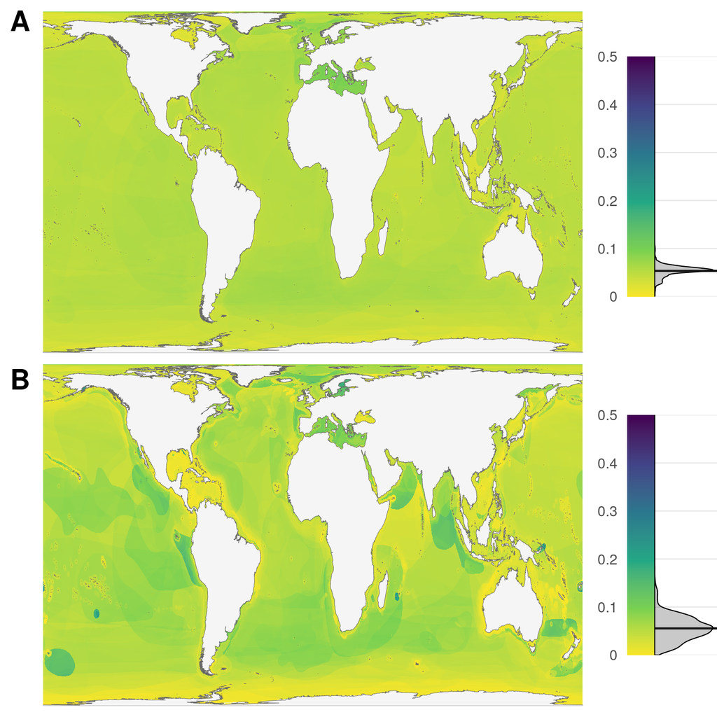

```r
var_cols <- c(viridis::viridis(6, direction = -1))
### set up a dataframe of values to craft a color bar using geom_segment
colorbar_df <- data.frame(x = seq(0, .5, length.out = 1000), y = -1)
lbls = c(0, .1, .2, .3, .4, .5)
brks = c(0, .1, .2, .3, .4, .5)
lims = c(0, .5)


land_poly <- sf::read_sf(file.path(dir_spatial, 'ne_10m_land',
                                   'ne_10m_land_no_casp.shp')) %>%
  st_transform(gp_proj4)

var_map_df <- data.frame(val_1 = values(var_un_rast),
                     val_2 = values(var_rr_rast)) %>%
  cbind(coordinates(var_un_rast)) %>%
  filter(!is.na(val_1))
### unweighted max = .18
### rr weighted max = .499

map1 <- ggplot(var_map_df) +
  geom_raster(aes(x, y, fill = val_1), show.legend = FALSE) +
  geom_sf(data = land_poly, aes(geometry = geometry),
          fill = 'grey96', color = 'grey40', size = .10) +
  ggtheme_map() +
  theme(plot.margin = unit(c(.2, 0, .1, .5), units = 'cm')) +
  coord_sf(datum = NA) + ### ditch graticules
  scale_fill_gradientn(colors = var_cols, labels = lbls,
                       breaks = brks, limits = lims) +
  scale_x_continuous(expand = c(0, 0)) +
  scale_y_continuous(expand = c(0, 0))

map2 <- ggplot(var_map_df) +
  geom_raster(aes(x, y, fill = val_2), show.legend = FALSE) +
  geom_sf(data = land_poly, aes(geometry = geometry),
          fill = 'grey96', color = 'grey40', size = .10) +
  ggtheme_map() +
  theme(plot.margin = unit(c(.1, 0, .2, .5), units = 'cm')) +
  coord_sf(datum = NA) + ### ditch graticules
  scale_fill_gradientn(colors = var_cols, labels = lbls,
                       breaks = brks, limits = lims) +
  scale_x_continuous(expand = c(0, 0)) +
  scale_y_continuous(expand = c(0, 0))

###################


dens1 <- ggplot(var_map_df) +
  ggtheme_plot() +
  geom_vline(xintercept = mean(var_map_df$val_1, na.rm = TRUE)) +
  geom_segment(data = colorbar_df,
               aes(x = x, xend = x, color = x),
               y = 0, yend = -10, size = 1,
               show.legend = FALSE) +
  geom_density(aes(x = val_1, ..scaled..),
               adjust = 5,
               alpha = .3, size = .25, fill = 'grey30') +
  scale_color_gradientn(colors = var_cols, labels = lbls,
                        breaks = brks, limits = lims) +
  theme(axis.text.x  = element_blank(),
        axis.title = element_blank(),
        panel.grid.major.x = element_blank(),
        plot.margin = unit(c(1, 0, 1, 0), units = 'cm')) +
  scale_x_continuous(labels = lbls, breaks = brks,
                     expand = c(0, 0)) +
  scale_y_continuous(limits = c(-.4, 1)) +
  coord_flip()

dens2 <- ggplot(var_map_df) +
  ggtheme_plot() +
  geom_vline(xintercept = mean(var_map_df$val_2, na.rm = TRUE)) +
  geom_segment(data = colorbar_df,
               aes(x = x, xend = x, color = x),
               y = 0, yend = -10, size = 1,
               show.legend = FALSE) +
  geom_density(aes(x = val_2, ..scaled..),
               adjust = 5,
               alpha = .3, size = .25, fill = 'grey30') +
  scale_color_gradientn(colors = var_cols, labels = lbls,
                        breaks = brks, limits = lims) +
  theme(axis.text.x  = element_blank(),
        axis.title = element_blank(),
        panel.grid.major.x = element_blank(),
        plot.margin = unit(c(1, 0, 1, 0), units = 'cm')) +
  scale_x_continuous(labels = lbls, breaks = brks,
                     expand = c(0, 0)) +
  scale_y_continuous(limits = c(-.4, 1)) +
  coord_flip()

panel_left <- cowplot::plot_grid(map1, dens1,
                                axis = 'b',
                                rel_widths = c(5, 1))
panel_right <- cowplot::plot_grid(map2, dens2,
                                axis = 'b',
                                rel_widths = c(5, 1))

four_panel <- cowplot::plot_grid(panel_left, panel_right,
                                 labels = c('A', 'B'),
                                 nrow = 2, ncol = 1, align = 'v')

figS3_path <- file.path(dir_git, 'ms_figures/fig_S4_var_maps.png')
ggsave(plot = four_panel,
       filename = figS3_path,
       width = 5, height = 5, units = 'in', dpi = 300)
```